# **[Universidade Federal Rural de Pernambuco](http://ufrpe.br/)** **[Departamento de Matemática](http://www.dm.ufrpe.br/)** **[Disciplina: Análise Combinatória](https://sites.google.com/site/ricardonunesmachadojr/disciplinas/analise-combinatoria)** **[Prof. Ricardo Machado](https://sites.google.com/site/ricardonunesmachadojr/)**

## [Índice de Aulas](https://sagectu.com.br/calculo1.github.io/combinatoria.html) Aula 3

## 1 - Permutação Circular 2 - Permutação com Repetição 3 - Exercícios 4 - Atividade 5 - Resposta dos Exercícios

# Referências:

### Observação: Nota de aula produzida usando o software [SageMath](http://www.sagemath.org/), usando o notebook [Jupyter](https://jupyter.org/). Use o SageMathCell com vários exemplos em: sagectu.com.br/sagecell.html Referência bibliográfica sobre o SageMath: [1] Silva, L., Santos M., Machado, R., [*Elementos de Computação Matemática com SageMath*](https://sagectu.com.br/), SBM, 2019.

[figure not shown]

```python
load ('/home/ricardo/sage-9.0-Debian_GNU_Linux_9-x86_64/SageMath/Sage_Sync/Combinatoria/codigos.sage')
```

## 1 - Permutação Circular

### Definição 1 O número de *permutações circulares* de $n$ elementos, é o número de maneiras de organizar $n$ objetos distintos ao longo de um círculo fixo (isto é, não pode ser retirado do plano e virado). Notação: $$ PC_n ~~\text{ ou }~~ PC(n). $$

### Exemplo 1 O três circulos seguintes são equivalentes.

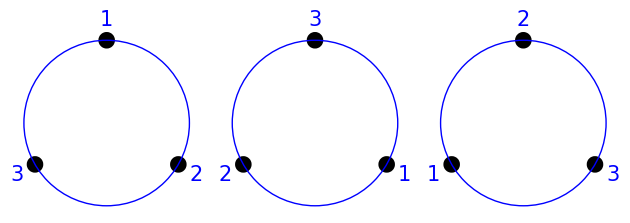

```python
p1 = permuta_circular_x([1, 2, 3])
p2 = permuta_circular_x([3, 1, 2])
p3 = permuta_circular_x([2, 3, 1])
G = graphics_array([[p1, p2, p3]])
G.show()
```

### Exemplo 2 O número total de permutações circulares com 3 elementos $\{1, 2, 3\}$ é 2.

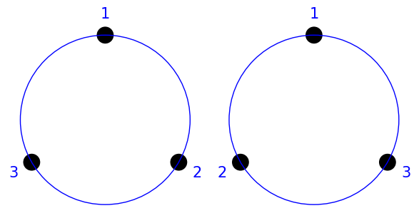

```python
p1 = permuta_circular_x([1, 2, 3])
p2 = permuta_circular_x([1, 3, 2])
G = graphics_array([[p1, p2]])
G.show()
```

### Teorema 1 $$ PC(n) = (n-1)! $$

### Demonstração Se não considerássemos equivalentes disposições que possam coincidir por rotação, teríamos $n!$ disposições. Como para cada disposição, temos $n$ disposições equivalentes, temos $$ PC(n) = \frac{n!}{n} = (n-1)! $$ $\blacksquare$

### Permutações Circulares no SageMath Vamos definir a função `PC(n)` no SageMath. `PC(n) = P(n)/n`

```python
PC(n) = P(n)/n
```

### Exemplo 3 Quantas rodas de ciranda podem ser formadas com 8 pessoas? $\blacksquare$

### Solução Basta calcular o número de permutações circulares de 8 elementos. $$ PC(8) = 5040. $$ $\blacksquare$

```python
PC(8)
```

```
5040
```

### Exemplo 4 Quantas rodas de ciranda podem ser formadas com 8 pessoas, se duas determinadas pessoas não podem ficar juntas?

### Solução Podemos calcular o número de permutações circulares de 8 elementos e subtrair o número de permutações de 8 elementos, na qual, dois deles estão juntos.

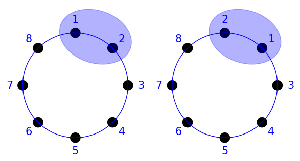

```python
p1 = permuta_circular_x([1, 2, 3, 4, 5, 6, 7, 8]) + ellipse((sin(pi/8), cos(pi/8)), 0.5, 0.7, pi/(2.5), fill='true', alpha=0.3)
p2 = permuta_circular_x([2, 1, 3, 4, 5, 6, 7, 8]) + ellipse((sin(pi/8), cos(pi/8)), 0.5, 0.7, pi/(2.5), fill='true', alpha=0.3)

G = graphics_array([[p1, p2]])
G.show()
```

### Neste caso, teremos $PC(7)\times 2$. Portanto a resposta é $$ PC(8)-PC(7)\times2 = 3600. $$ $\blacksquare$

```python
PC(8)-PC(7)*2
```

```
3600
```

## 2 - Permutação com Repetição

### Exemplo 5 Quantos são os anagramas da palavra SAGEMATH?

### Solução Observe que a palavra SAGEMATH possui 8 letras, mas a letra A aparece duas vezes, o restante aparece apenas uma vez. Podemos imaginar, por enquanto, que a palavra é assim $$SA_1GEMA_2TH$$ Com $A_1\neq A_2$, nesse caso teríamos um total de $$ P(8) = 8! $$ permutações. Agora vamos resolver o problema das repetições. Observe que para cada permutação, trocar os A's de lugar não muda o anagrama, portanto, precisamos dividir o total de permutações pela quantidade de reordenar os A's. Dessa forma a resposta é $$\frac{P(8)}{P(2)}=20160.$$

```python
P(8)/P(2)
```

```
20160
```

### Definição 2 Quando temos um conjunto de $n$ objetos, que possui elementos repetidos, o número de *permutações com repetições* é denotado por: $$ PR_n^{r_1, r_2, \ldots, r_k}. $$ Na qual, $r_i$ é o número de repetições do i-ésimo objeto.

### Teorema 2 $$ PR_n^{r_1, r_2, \ldots, r_k} = \frac{n!}{r_1!\times r_2!\times\cdots\times r_k!}. $$

### Demonstração Considere os $n$ objetos da seguinte forma: $$ \underbrace{A_1A_1\ldots A_1}_{r_1 \text{ vezes}} \underbrace{A_2A_2\ldots A_2}_{r_2 \text{ vezes}}\ldots\underbrace{A_kA_k\ldots A_k}_{r_k \text{ vezes}} $$ observe que $r_1+r_2+\cdots+ r_k = n.$ Para encontrar o número de formar de permutar esses elementos, vamos quebrar em $k$ etapas. Na primeira etapa, vamos escolher $r_1$ posições, dentre $n$, para colocar $A_1$: $C_n^{r_1}$. Na segunda etapa, vamos escolher $r_2$ posições, dentre $n-r_1$, para colocar $A_2$: $C_{n-r_1}^{r_2}$. $\vdots$ Na $k$-ésima etapa, vamos escolher $r_k$ posições, dentre $n-r_1-r_2-\cdots-r_{k-1}=r_k$, para colocar $A_k$: $C_{r_k}^{r_k}$. Portanto, \begin{equation*} \begin{split} PR_n^{r_1, r_2, \ldots, r_k} &=~ C_n^{r_1}\times C_{n-r_1}^{r_2} \times \cdots \times C_{r_k}^{r_k} \\ &=~ \frac{n!}{r_1!\underbrace{(n-r_1)!}_{x_1}}\cdot\frac{\overbrace{(n-r_1)!}^{x_1}}{r_2!\underbrace{(n-r_1-r_2)!}_{x_2}}\cdot \frac{\overbrace{(n-r_1-r_2)!}^{x_2}}{r_3!\underbrace{(n-r_1-r_2-r_3)!}_{x_3}}\cdots\frac{\overbrace{n_k!}^{x_k}}{n_k!\underbrace{(n_k-n_k)!}_{=1}} \\ &=~ \frac{n!}{r_1!\times r_2!\times\cdots\times r_k!}. \end{split} \end{equation*} $\blacksquare$

### Número de Permutações com Repetições no SageMath Vamos definir a função `PR()` no SageMath.

```python
def PR(*lista):

    p = P(lista[0])
    for i in lista[1:]:
        p = p/P(i)

    return p
```

### Exemplo 6 Quantos são os anagramas da palavra MATEMATICA?

### Solução $$ PR_{10}^{3, 2, 2} = 151200. $$

```python
PR(10, 3, 2, 2)
```

```
151200
```

### Exemplo 7 Quantos são os anagramas da palavra MATEMATICA que começam por vogal?

### Solução Se o anagrama começa por vogal, temos as possibilidades, A, E ou I. Começando com A, temos um total de $PR_9^{2, 2, 2}$ Começando com E, temos um total de $PR_9^{3, 2, 2}$ Começando com I, temos um total de $PR_9^{3, 2, 2}$ Portanto a resposta é $$ PR_9^{2, 2, 2} + 2\times PR_9^{3, 2, 2} = 75600. $$

```python
PR(9, 2, 2, 2) + 2*PR(9, 3, 2, 2)
```

```
75600
```